# Assessed Practical 1

Kai Lawson-McDowall

Aim: Investigate how the number of medals a country wins can be predicted from national population and GDP, and how consistent these relationships are.

Regression Tasks:

1- Perform a linear regression to predict medal count in 2008 and 2012 using population and GDP, Explain the model and the approach to learn about the model parameters, report your results and comment on your findings:

I generated two multiple linear regression models using the GLM command using GDP (Beta1) and population (Beta2) as explanatory variables and medals either in 2008 or 2012 as the response variable. The summary() of these models showed that the 2008 model produced parameter estimates for GDP of 7.61e-03 (95 CI:6.15e-03 to 9.08e-03, p-value = 1.29e-15) and for population of 8.44e-09 (95 CI:-5.97e-09 to 2.28e-08, P-value = 0.246750). The 2012 model had parameter estimates for GDP of 7.56e-03 (95 CI: 6.1e-03 9.03e-03, P-value = 1.45e-15) and for Population of 5.25e-09 (95 CI:-9.11 e-09 to 1.96e-08, p-value = 0.468225). In the 2008 model,the intercept (Beta0) was 5.613 (95 CI: 2.61 to 8.62, P-value = 0.000395 ), in the 2012 model, this was 6.08 (95 CI: 3.08 to 9.07, p-value = 0.000133)

In both models, the GDP parameter estimates are positive and have significant p-values, indicating that an increase in GDP leads to an increase in the number of medals predicted. However, for population, The 95% CI for population in both the 2008 and 2012 models contains 0. Therefore, it cannot be said with certainty that population has a relationship with medal count (hence, it’s insignificant p-values in both models).Although the values for both the intercepts were significant based on their p-values, and implied that when population and GDP both equal 0, that 5.613 medals (2008) and 6.08 medals (2012) would be won. An argument could be made that the intercept could be set to 0 when both equal 0, as if a country population = 0, then there is no one to win medals, or even generate a GDP.

```r
# changed name of the dataframe to "onegold" upon import
onegold <-medal_pop_gdp_data_statlearn
summary(onegold)
```

```
   Country               GDP             Population          Medal2008        Medal2012
 Length:71          Min.   :    6.52   Min.   :3.537e+05   Min.   :  1.00   Min.   :  1.0
 Class :character   1st Qu.:   51.52   1st Qu.:5.513e+06   1st Qu.:  2.00   1st Qu.:  3.0
 Mode  :character   Median :  229.53   Median :1.673e+07   Median :  6.00   Median :  6.0
                    Mean   :  903.25   Mean   :7.384e+07   Mean   : 13.11   Mean   : 13.3
                    3rd Qu.:  704.37   3rd Qu.:4.958e+07   3rd Qu.: 13.50   3rd Qu.: 13.0
                    Max.   :15094.00   Max.   :1.347e+09   Max.   :110.00   Max.   :104.0
   Medal2016
 Min.   :  1.00
 1st Qu.:  3.00
 Median :  7.00
 Mean   : 13.44
 3rd Qu.: 15.00
 Max.   :121.00
```

```r
str(onegold)
```

```
'data.frame':   71 obs. of  6 variables:
 $ Country   : chr  "Algeria" "Argentina" "Armenia" "Australia" ...
 $ GDP       : num  188.7 446 10.2 1371.8 63.4 ...
 $ Population: int  37100000 40117096 3268500 22880619 9111100 353658 1234571 9461400 10951266 192376496 ...
 $ Medal2008 : int  2 6 6 46 7 2 1 19 2 15 ...
 $ Medal2012 : int  1 4 3 35 10 1 1 12 3 17 ...
 $ Medal2016 : int  2 4 4 29 18 2 2 9 6 19 ...
```

```r
#quick summary statistics

#linear regression models: 2008

model2008 <- glm(Medal2008 ~ GDP+Population, data = onegold)
summary(model2008)
```

```
Call:
glm(formula = Medal2008 ~ GDP + Population, data = onegold)

Deviance Residuals:
    Min       1Q   Median       3Q      Max
-27.154   -4.856   -1.702    0.842   51.037

Coefficients:
             Estimate Std. Error t value Pr(>|t|)
(Intercept) 5.613e+00  1.506e+00   3.728 0.000395 ***
GDP         7.613e-03  7.353e-04  10.354 1.29e-15 ***
Population  8.435e-09  7.220e-09   1.168 0.246750
---
Signif. codes:  0 ‘***’ 0.001 ‘**’ 0.01 ‘*’ 0.05 ‘.’ 0.1 ‘ ’ 1

(Dispersion parameter for gaussian family taken to be 133.1455)

    Null deviance: 29595.1  on 70  degrees of freedom
Residual deviance:  9053.9  on 68  degrees of freedom
AIC: 553.72

Number of Fisher Scoring iterations: 2
```

```r
confint(model2008)
```

```
                    2.5 %       97.5 %
(Intercept)  2.662429e+00 8.564106e+00
GDP          6.172018e-03 9.054252e-03
Population  -5.715152e-09 2.258480e-08
```

```r
n = length(onegold$Country)
print(n)
```

```
[1] 71
```

```r
tc = qt(p=0.975, df=68) # used 3 parameters, and therefore had 68 DFs

CIINT2008 = summary(model2008)$coefficients[1, 1] + # confidence interval for the intercept in 2008
c(-1,1)*tc*summary(model2008)$coefficients[1, 2]
print(CIINT2008)
```

```
[1] 2.608974 8.617561
```

```r
CIGDP2008 = summary(model2008)$coefficients[2, 1] + # confidence interval for GDP in 2008
c(-1,1)*tc*summary(model2008)$coefficients[2, 2]
print(CIGDP2008)
```

```
[1] 0.006145912 0.009080358
```

```r
CIPOP2008 = summary(model2008)$coefficients[3, 1] + # confidence interval for Population in 2008
c(-1,1)*tc*summary(model2008)$coefficients[3, 2]
print(CIPOP2008)
```

```
[1] -5.971481e-09  2.284113e-08
```

```r
#It should also be noted that these confidence intervals can be obtained through the combination of the LM() and confint() functions

#linear regression models: 2012

model2012 <- glm(Medal2012 ~ GDP+Population, data = onegold)
summary(model2012)
```

```
Call:
glm(formula = Medal2012 ~ GDP + Population, data = onegold)

Deviance Residuals:
    Min       1Q   Median       3Q      Max
-20.568   -5.961   -2.462    3.932   60.121

Coefficients:
             Estimate Std. Error t value Pr(>|t|)
(Intercept) 6.076e+00  1.500e+00   4.051 0.000133 ***
GDP         7.564e-03  7.325e-04  10.326 1.45e-15 ***
Population  5.247e-09  7.193e-09   0.729 0.468225
---
Signif. codes:  0 ‘***’ 0.001 ‘**’ 0.01 ‘*’ 0.05 ‘.’ 0.1 ‘ ’ 1

(Dispersion parameter for gaussian family taken to be 132.1562)

    Null deviance: 28402.8  on 70  degrees of freedom
Residual deviance:  8986.6  on 68  degrees of freedom
AIC: 553.19

Number of Fisher Scoring iterations: 2
```

```r
CIINT2012 = summary(model2012)$coefficients[1, 1] + # confidence interval for GDP in 2012
c(-1,1)*tc*summary(model2012)$coefficients[1, 2]
print(CIINT2012)
```

```
[1] 3.082981 9.069203
```

```r
CIGDP2012 = summary(model2012)$coefficients[2, 1] + # confidence interval for GDP in 2012
c(-1,1)*tc*summary(model2012)$coefficients[2, 2]
print(CIGDP2012)
```

```
[1] 0.006102319 0.009025843
```

```r
CIPOP2012 = summary(model2012)$coefficients[3, 1] + # confidence interval for Population in 2012
c(-1,1)*tc*summary(model2012)$coefficients[3, 2]
print(CIPOP2012)
```

```
[1] -9.105934e-09  1.959943e-08
```

```r
#creating a new dataframe to put the predictions in:
rm(predictions_2008_and_2012)
predictions_2008_and_2012<- data.frame(Country = onegold$Country, Population = onegold$Population, GDP = onegold$GDP)
#Adding the real and predicted data to the new df

#2008
predictions_2008_and_2012['Actual_2008'] <- onegold$Medal2008
predictions_2008_and_2012['Predicted_2008'] <- predict(model2008)

#2012
predictions_2008_and_2012['Actual_2012'] <- onegold$Medal2012
predictions_2008_and_2012['Predicted_2012'] <- predict(model2012)

predictions_2008_and_2012
```

| Country | Population | GDP | Actual_2008 | Predicted_2008 | Actual_2012 | Predicted_2012 |
| --- | --- | --- | --- | --- | --- | --- |
| Algeria | 37100000 | 188.68 | 2 | 7.362646 | 1 | 7.697937 |
| Argentina | 40117096 | 445.99 | 6 | 9.347030 | 4 | 9.660081 |
| Armenia | 3268500 | 10.25 | 6 | 5.718871 | 3 | 6.170773 |
| Australia | 22880619 | 1371.76 | 46 | 16.249655 | 35 | 16.572245 |
| Azerbaijan | 9111100 | 63.40 | 7 | 6.172791 | 10 | 6.603459 |
| Bahamas | 353658 | 7.79 | 2 | 5.675557 | 1 | 6.136872 |
| Bahrain | 1234571 | 21.90 | 1 | 5.790408 | 1 | 6.248223 |
| Belarus | 9461400 | 55.14 | 19 | 6.112861 | 12 | 6.542817 |
| Belgium | 10951266 | 511.53 | 2 | 9.599986 | 3 | 10.002805 |
| Brazil | 192376496 | 2476.65 | 15 | 26.091000 | 17 | 25.819025 |

[output cut: 61 more lines]

2. How consistent are the effects of Population and GDP over time?

One way to determine if the effects of population and GDP over time is to plot the medal counts from both the 2008 and 2012 models against one another. This is performed in the code below. Assuming that the effects of population and time were the same over time, we would expect the 2008 and 2012 models to be equal to each other (same predicted log(medal) values). As illustrated in the graph, the number of medals predicted in 2008 and 2012 based on population and GDP as explanatory variables are highly similar (all values lying on the trendline except for 3), indicating that the effects of GDP and population are consistent over time.I also calculated the pearsons’ correlation coefficient (0.9994, p-value = 2.2e-16) which measures is a measure of linear correlation between two sets of data (in this case the predicted medals from each model). The high correlation and very small p- value further indicate the consistency of GDP and population over time.

```r
rm(Medalplot)

res <-cor.test(predictions_2008_and_2012$Predicted_2008, predictions_2008_and_2012$Predicted_2012, method=c("pearson"))
res
```

```
    Pearson's product-moment correlation

data:  predictions_2008_and_2012$Predicted_2008 and predictions_2008_and_2012$Predicted_2012
t = 244.33, df = 69, p-value < 2.2e-16
alternative hypothesis: true correlation is not equal to 0
95 percent confidence interval:
 0.9990713 0.9996410
sample estimates:
      cor
0.9994226
```

[figure not shown]

```r
# Log transformed the medals
library(ggplot2)
Medalplot <- ggplot(predictions_2008_and_2012, aes(x=log(Predicted_2008), y=log(Predicted_2012))) +
  geom_point(size=2, shape=1) + xlab("Log2(Medals predicted in 2008)") +
  ylab("Log2(Medals predicted in 2012)") + geom_smooth(method = lm)
Medalplot
```

3. Using the regression for the 2012 medal count make a prediction for the results of 2016

The below used the “model2012” model to predict the medal count in 2016, I then appended this to a new dataframe “newdata” which only contains country, population, gdp, predicted medals in 2016, and actual medals in 2016. I also rounded the values for predicted medals (as they are count data). It also worth noting that, although we have predicted the 2016 medal count from the 2012 medal count, there is only measurement of GDP and population each. These are being recycled through the 2012 model to predict the 2016 medals, and so GDP and population values that correspond to 2016 would be better inputs to predict 2016 medal count. However, as the parameter estimates for GDP and population are very small (e.g. 7.56e-03 for GDP in the 2012 model), it would take quite large changes in GDP and population for there to be any large effect on the predicted medal count.

```r
library(dplyr)

rm(newdata)
newdata = data.frame(Country = onegold$Country, Population = onegold$Population, GDP = onegold$GDP)
newdata
```

| Country | Population | GDP |
| --- | --- | --- |
| Algeria | 37100000 | 188.68 |
| Argentina | 40117096 | 445.99 |
| Armenia | 3268500 | 10.25 |
| Australia | 22880619 | 1371.76 |
| Azerbaijan | 9111100 | 63.40 |
| Bahamas | 353658 | 7.79 |
| Bahrain | 1234571 | 21.90 |
| Belarus | 9461400 | 55.14 |
| Belgium | 10951266 | 511.53 |
| Brazil | 192376496 | 2476.65 |

[output cut: 61 more lines]

```r
predictions_2016 = predict(model2012, newdata)
predictions_2016
```

```
         1          2          3          4          5          6          7          8          9
  7.697937   9.660081   6.170773  16.572245   6.603459   6.136872   6.248223   6.542817  10.002805
        10         11         12         13         14         15         16         17         18
 25.819025   6.519486  19.390152  68.348721   8.828562   6.581570   6.595043   7.759147   8.621790
        19         20         21         22         23         24         25         26         27
  6.545939   8.242126   6.250779   6.758360   8.117037  27.394391   6.208237  33.513444  24.795509
        28         29         30         31         32         33         34         35         36
  8.392310   7.187558  26.568161  13.728427   7.130986   7.743689  22.996238   6.204280  51.125438
        37         38         39         40         41         42         43         44         45
  7.572239   6.532974   6.416057   8.332637  15.404428   6.147716   6.155200   7.004824  12.489418
        46         47         48         49         50         51         52         53         54
  7.087823   6.368698   9.776986  10.169817   7.928127   7.535952  20.878996   6.454139   7.916400
        55         56         57         58         59         60         61         62         63
  6.830738   6.461612   9.429469  14.774385  17.595080  10.196346  10.925493   9.722857   6.165369
        64         65         66         67         68         69         70         71
  9.034171   6.253046   6.478984  12.315867   7.565541 121.892569   6.572002   8.612422
```

```r
newdata['Predicted'] <- predictions_2016 #adds the data to the df
newdata ['Actual' ]<- onegold$Medal2016# same as above
newdata <- newdata %>% mutate(across(starts_with("Predicted"), round, 0)) #Round to whole numbers
newdata
```

| Country | Population | GDP | Predicted | Actual |
| --- | --- | --- | --- | --- |
| Algeria | 37100000 | 188.68 | 8 | 2 |
| Argentina | 40117096 | 445.99 | 10 | 4 |
| Armenia | 3268500 | 10.25 | 6 | 4 |
| Australia | 22880619 | 1371.76 | 17 | 29 |
| Azerbaijan | 9111100 | 63.40 | 7 | 18 |
| Bahamas | 353658 | 7.79 | 6 | 2 |
| Bahrain | 1234571 | 21.90 | 6 | 2 |
| Belarus | 9461400 | 55.14 | 7 | 9 |
| Belgium | 10951266 | 511.53 | 10 | 6 |
| Brazil | 192376496 | 2476.65 | 26 | 19 |

[output cut: 61 more lines]

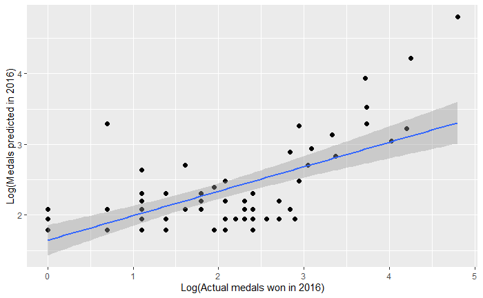

```r
library(ggplot2)

APplot <- ggplot(newdata, aes(x=log(Actual), y=log(Predicted))) +
  geom_point(size=2, shape=16) + xlab("Log(Actual medals won in 2016)") +
  ylab("Log(Medals predicted in 2016)") + geom_smooth(method = lm) # the glm vs lm doesn't appear to make a difference to the plot
#transformed the medal counts to log2 values.
APplot
```

```r
# Get fit, and make a variable with labels for points outside CIs
fit <- lm(newdata$Predicted~newdata$Actual)
dat <- predict.lm(fit, interval="confidence") #creates a dataframe with the fit, lower and upper CI's
newdata$outside <- ifelse(newdata$Actual < dat[,"upr"] & newdata$Actual > dat[,"lwr"], "", as.character(newdata$Country)) # adds a column "outside" with a country name if it is outside the CI's below
```

MODEL SELECTION TASKS:

1. Fit linear regressions models for the total medal count in 2012 using: (i) Population alone; (ii) GDP alone; (iii) Population and GDP. Perform model selection using the Akaike Information Criterion and report your results.

The AICs for model1 (GDP), model2 (Population), and model3 (GDP + population) are 551.74,618.15, and 553.19 respectively. Although model2 has a larger AIC relative to the others. The AICs of model1 and model3 are fairly similar, therefore, we should compare these. Model3 is exp(551.74-553.2)/2), or 0.482 times as probable as model 1, indicating it might not be the best choice. Conversely, one rule of thumb is that models within 1-2 of the minimum AIC have substantial support, suggesting that model3 could be acceptable.

```r
model1 <- glm(Medal2012~GDP, data = onegold)
model2 <- glm(Medal2012~Population, data = onegold)
model3 <- glm(Medal2012~GDP+Population, data = onegold)

summary(model1) #summary of GLMs includes AIC
```

```
Call:
glm(formula = Medal2012 ~ GDP, data = onegold)

Deviance Residuals:
    Min       1Q   Median       3Q      Max
-20.211   -6.025   -2.590    3.885   60.244

Coefficients:
             Estimate Std. Error t value Pr(>|t|)
(Intercept) 6.2359593  1.4788174   4.217 7.39e-05 ***
GDP         0.0078160  0.0006438  12.140  < 2e-16 ***
---
Signif. codes:  0 ‘***’ 0.001 ‘**’ 0.01 ‘*’ 0.05 ‘.’ 0.1 ‘ ’ 1

(Dispersion parameter for gaussian family taken to be 131.2601)

    Null deviance: 28402.8  on 70  degrees of freedom
Residual deviance:  9056.9  on 69  degrees of freedom
AIC: 551.74

Number of Fisher Scoring iterations: 2
```

```r
summary(model2)
```

```
Call:
glm(formula = Medal2012 ~ Population, data = onegold)

Deviance Residuals:
    Min       1Q   Median       3Q      Max
-54.311   -8.421   -5.507    1.786   81.059

Coefficients:
             Estimate Std. Error t value Pr(>|t|)
(Intercept) 1.032e+01  2.295e+00   4.498  2.7e-05 ***
Population  4.026e-08  1.009e-08   3.990 0.000162 ***
---
Signif. codes:  0 ‘***’ 0.001 ‘**’ 0.01 ‘*’ 0.05 ‘.’ 0.1 ‘ ’ 1

(Dispersion parameter for gaussian family taken to be 334.4558)

    Null deviance: 28403  on 70  degrees of freedom
Residual deviance: 23077  on 69  degrees of freedom
AIC: 618.15

Number of Fisher Scoring iterations: 2
```

```r
summary(model3)
```

```
Call:
glm(formula = Medal2012 ~ GDP + Population, data = onegold)

Deviance Residuals:
    Min       1Q   Median       3Q      Max
-20.568   -5.961   -2.462    3.932   60.121

Coefficients:
             Estimate Std. Error t value Pr(>|t|)
(Intercept) 6.076e+00  1.500e+00   4.051 0.000133 ***
GDP         7.564e-03  7.325e-04  10.326 1.45e-15 ***
Population  5.247e-09  7.193e-09   0.729 0.468225
---
Signif. codes:  0 ‘***’ 0.001 ‘**’ 0.01 ‘*’ 0.05 ‘.’ 0.1 ‘ ’ 1

(Dispersion parameter for gaussian family taken to be 132.1562)

    Null deviance: 28402.8  on 70  degrees of freedom
Residual deviance:  8986.6  on 68  degrees of freedom
AIC: 553.19

Number of Fisher Scoring iterations: 2
```

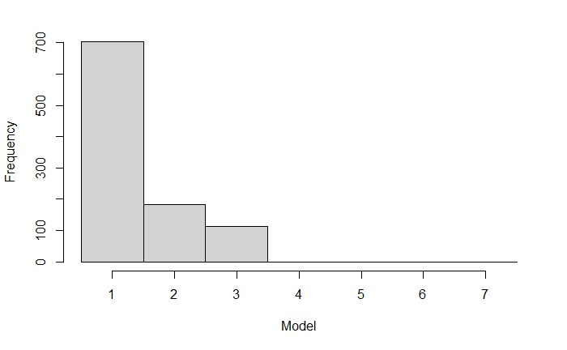

```r
x1 = onegold$Medal2012
x2 = onegold$GDP
x3 = onegold$Population

cvdata = data.frame(x2,x3, x1) # had issues using onegold data frame so created this

#Repeat cross validation 1000 times

winner = rep(NA, 1000)
for (iteration in 1:1000){

trainRows<-runif(nrow(cvdata))>0.60 #randomly put aside 60% of the data
training<-cvdata[trainRows,]# about 60% (42 rows training)
testing <-cvdata[!trainRows,]# about 40% testing (29 rows testing)


formulas = c("x1~x2", "x1~x3","x1~x2+x3") #list the possible models 1,2, and 3 respectively in graphs.
predictive_log_likelihood = rep(NA, length(formulas)) #Replicate elements of vectors and lists

#Loop

for (i in 1:length(formulas)){

current_model = glm(formula = formulas[i], data = training) #First, fit model with training data
sigma = sqrt(summary(current_model)$dispersion) #Extract 'dispersion parameter'
ypredict_mean = predict(current_model, testing) #Get the predicted mean for each new data point
predictive_log_likelihood[i] = sum(dnorm(testing$x1, ypredict_mean, sigma, log=TRUE))
#Now calculate the predictive log probability through summing the  log probabilities of each output value in the test data
}

winner[iteration] = which.max(predictive_log_likelihood)
}

hist(winner, breaks = seq(0.5, 7.5, 1), xlab='Model', ylab='Frequency', main='')# The histogram showing how many times each model won out of 1000.
```

```r
rmse(preddata$Actual,preddata$`Model 3 Predictions (GDP + Population)`)
```

```
[1] 9.086439
```